# Peer-graded Assignment: Milestone Report

EPriske

26 11 2021

## Summary

The goal of this project is just to display that you’ve gotten used to working with the data and that you are on track to create your prediction algorithm. We want to do an exploratory analysis of the data we are going to work with, we will use the USA data set given to us by “Corpora” (The corpora are collected from publicly available sources by a web crawler. The crawler checks for language, so as to mainly get texts consisting of the desired language*.)

First we will start by loading the required libraries for our exploratory analysis.

```r
library(ggplot2)
library(lubridate)
library(RColorBrewer)
library(ngram)
library(dplyr)
library(RWeka)
library(forcats)
```

Then we will add the files needed for analysis to our working directory. While using the Coursera Rstudio Sandbox, it is difficult to download documents directly using code, so what I did was to download the Zip and then upload only the files needed for this Capstone project. I created a folder called Capstone, and uploaded the US files there. Next step is to read the lines of every file and store them in variables.

Because of RAM limitations on my RStudio Cloud (1 GB RAM) I put a limit in the lines readed by the function readLines, the limit was set at 50,000 lines.

```r
setwd("/cloud/project/Capstone")
destfile = "./Coursera-SwiftKey.zip"
if(!file.exists(destfile)){
  url = "https://d396qusza40orc.cloudfront.net/dsscapstone/dataset/Coursera-SwiftKey.zip"
  file <- basename(url)
  download.file(url, file, method="curl")
  unzip(file)
}

twitter <- readLines("/cloud/project/Capstone/final/en_US/en_US.twitter.txt", n = 50000, encoding = 'UTF-8',warn = FALSE)
news <- readLines("/cloud/project/Capstone/final/en_US/en_US.news.txt", n = 50000, encoding = 'UTF-8',warn = FALSE)
blogs <- readLines("/cloud/project/Capstone/final/en_US/en_US.blogs.txt", n = 50000, encoding = 'UTF-8',warn = FALSE)
```

### Now we can start doing or exploratory analysis.

```r
#Number of lines per document.
SMatrix <- as.data.frame(cbind(rbind(length(news),length(twitter),length(blogs)),rbind(wordcount(news),wordcount(twitter),wordcount(blogs))))
names(SMatrix)<-c("#lines","#words")
rownames(SMatrix)<-c("news","twitter","blogs")
SMatrix
```

```
##         #lines  #words
## news     50000 1709982
## twitter  50000  642312
## blogs    50000 2063711
```

## Training Set

```r
set.seed(99999)

TRblogs <- sample(blogs, length(blogs)*0.05)
TRnews <- sample(news, length(news)*0.05)
TRtwitter <- sample(twitter, length(twitter)*0.05)
Training=c(TRblogs,TRnews,TRtwitter)

length(Training)
```

```
## [1] 7500
```

```r
wordcount(Training)
```

```
## [1] 222689
```

“An n-gram is a sequence of n”words” taken from a body of text. This package offers utilities for creating, displaying, summarizing, and “babbling” n-grams. The tokenization and ‘babbling’ are handled by very efficient C code, which can even be build as its own standalone library. The babbler is a simple Markov chain.”

```r
unigram <- NGramTokenizer(Training, Weka_control(min = 1,max=1))
bigram <- NGramTokenizer(Training, Weka_control(min = 2,max= 2))
trigram <-NGramTokenizer(Training, Weka_control(min = 3, max=3))
unigram<-data.frame(table(unigram))%>%arrange(desc(Freq))
bigram<-data.frame(table(bigram))%>%arrange(desc(Freq))
trigram<-data.frame(table(trigram))%>%arrange(desc(Freq))

Tokens <- as.data.frame(cbind(unigram[1:15,],bigram[1:15,],trigram[1:15,]))
names(Tokens)[c(2,4,6)]<-c("FreqUn","FreqBi","FreqTri")
Tokens
```

```
##    unigram FreqUn   bigram FreqBi     trigram FreqTri
## 1      the   9978   of the    993    a lot of      68
## 2       to   5932   in the    911  one of the      60
## 3      and   5441   to the    496     I don t      49
## 4        a   5135   on the    444     I m not      42
## 5       of   4614  for the    335  the end of      42
## 6       in   3553    to be    322  out of the      38
## 7        I   3534  and the    305     I can t      37
## 8     that   2338      I m    291 some of the      37
## 9       is   2281   at the    284     to be a      37
## 10     for   2110     in a    254 going to be      36
## 11      it   1865     is a    220 part of the      32
## 12      on   1650 with the    220    I didn t      29
## 13       s   1613    for a    212  be able to      27
## 14     you   1571 from the    203  as well as      26
## 15    with   1551     it s    196      it s a      26
```

Using “ngram” we have a good overview of the most used words in our Training Dataset, we can see the most used word, the most used combination of 2 words and the most used combination of 3 words.

## Plotting our findings.

Now we want to plot this using ggplot2.

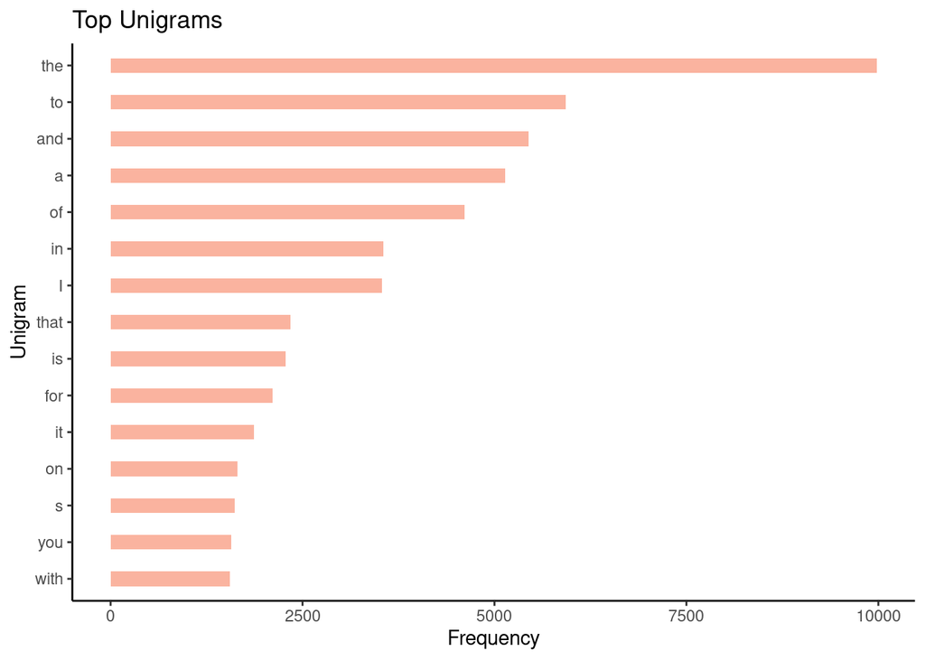

```r
Tokens %>%
  mutate(unigram = fct_reorder(unigram, FreqUn)) %>%
  ggplot(mapping = aes(x = unigram, y = FreqUn)) +
  geom_bar(stat="identity", fill="#f68060", alpha=.6, width=.4) +
  coord_flip() +
  xlab("Unigram") +
  ylab("Frequency") +
  ggtitle("Top Unigrams") +
  theme_classic()
```

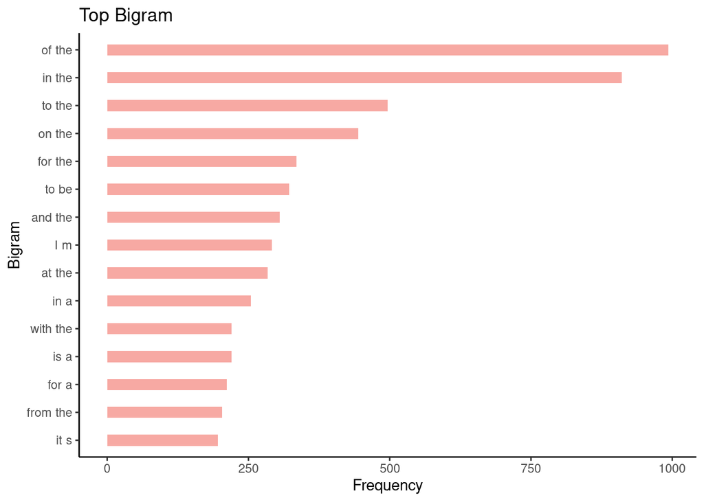

```r
Tokens %>%
  mutate(bigram = fct_reorder(bigram, FreqBi)) %>%
  ggplot(mapping = aes(x = bigram, y = FreqBi)) +
  geom_bar(stat="identity", fill="#f27066", alpha=.6, width=.4) +
  coord_flip() +
  xlab("Bigram") +
  ylab("Frequency") +
  ggtitle("Top Bigram") +
  theme_classic()
```

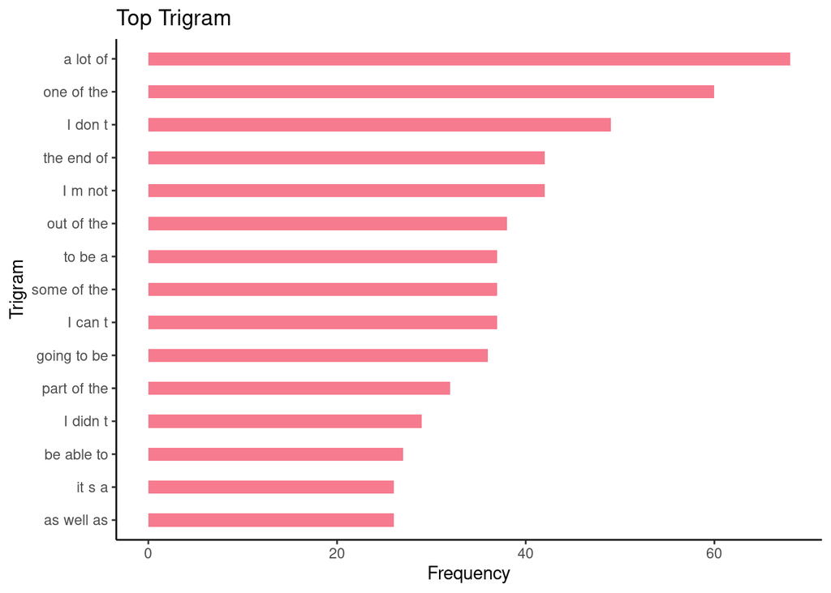

```r
Tokens %>%
  mutate(trigram = fct_reorder(trigram, FreqTri)) %>%
  ggplot(mapping = aes(x = trigram, y = FreqTri)) +
  geom_bar(stat="identity", fill="#f12345", alpha=.6, width=.4) +
  coord_flip() +
  xlab("Trigram") +
  ylab("Frequency") +
  ggtitle("Top Trigram") +
  theme_classic()
```